# [Python] DACON 인구 데이터 기반 소득 예측 경진대회

#### **분석 개요**

인구 데이터 바탕으로 소득이 5만달러 이하인지 초과인지 분류

주어진 데이터(train.csv)로 진행하여 대회 종류 후 제출한 결과는 아래와 같다.(2022-05-15)

**449팀 중 39위**이다.(닉네임:newhyh) 스코어 0.87123으로 1위 스코어와 0.006차이이다.

본 분석에서는 train데이터를 다시 분리하여 성능 평가까지 진행한다.

[figure not shown]

```python
from IPython.display import clear_output
from IPython.display import Image
Image('dacon0429.jpg')
```

```python
import pandas as pd
import numpy as np
import pickle
```

```python
import warnings
warnings.filterwarnings(action='ignore')
```

```python
dat = pd.read_csv('./data/train_1.csv')
```

**변수 설명**  
id : 샘플 아이디  
age : 나이  
workclass : 일 유형  
fnlwgt : CPS(Current Population Survey) 가중치  
education : 교육수준  
education.num : 교육수준 번호  
marital.status : 결혼 상태  
occupation : 직업  
relationship : 가족관계  
race : 인종  
sex : 성별  
capital.gain : 자본 이익  
capital.loss : 자본 손실  
hours.per.week : 주당 근무시간  
native.country : 본 국적  
target : 소득  
0 = <=50K (5만 달러 이하), 1 = >50K (5만 달러 초과)

```python
dat.info()
```

```
<class 'pandas.core.frame.DataFrame'>
RangeIndex: 17480 entries, 0 to 17479
Data columns (total 17 columns):
 #   Column          Non-Null Count  Dtype
---  ------          --------------  -----
 0   Unnamed: 0      17480 non-null  int64
 1   id              17480 non-null  int64
 2   age             17480 non-null  int64
 3   workclass       17480 non-null  object
 4   fnlwgt          17480 non-null  int64
 5   education       17480 non-null  object
 6   education.num   17480 non-null  int64
 7   marital.status  17480 non-null  object
 8   occupation      17480 non-null  object
 9   relationship    17480 non-null  object
 10  race            17480 non-null  object
 11  sex             17480 non-null  object
 12  capital.gain    17480 non-null  int64
 13  capital.loss    17480 non-null  int64
 14  hours.per.week  17480 non-null  int64
 15  native.country  17480 non-null  object
 16  target          17480 non-null  int64
dtypes: int64(9), object(8)
memory usage: 2.3+ MB
```

```python
dat.iloc[:5,1:10].head()
```

|  | id | age | workclass | fnlwgt | education | education.num | marital.status | occupation | relationship |
| --- | --- | --- | --- | --- | --- | --- | --- | --- | --- |
| 0 | 0 | 32 | Private | 309513 | Assoc-acdm | 12 | Married-civ-spouse | Craft-repair | Husband |
| 1 | 1 | 33 | Private | 205469 | Some-college | 10 | Married-civ-spouse | Exec-managerial | Husband |
| 2 | 2 | 46 | Private | 149949 | Some-college | 10 | Married-civ-spouse | Craft-repair | Husband |
| 3 | 3 | 23 | Private | 193090 | Bachelors | 13 | Never-married | Adm-clerical | Own-child |
| 4 | 4 | 55 | Private | 60193 | HS-grad | 9 | Divorced | Adm-clerical | Not-in-family |

```python
dat.iloc[:5,10:].head()
```

|  | race | sex | capital.gain | capital.loss | hours.per.week | native.country | target |
| --- | --- | --- | --- | --- | --- | --- | --- |
| 0 | White | Male | 0 | 0 | 40 | United-States | 0 |
| 1 | White | Male | 0 | 0 | 40 | United-States | 1 |
| 2 | White | Male | 0 | 0 | 40 | United-States | 0 |
| 3 | White | Female | 0 | 0 | 30 | United-States | 0 |
| 4 | White | Female | 0 | 0 | 40 | United-States | 0 |

education과 education.num은 학년을 범주형 수치형으로 구분한 것이므로 동일하다.  
EDA후 특이사항이 없으면 'education'을 삭제한다.

#### 결측 확인

```python
dat.isnull().sum()
```

```
Unnamed: 0        0
id                0
age               0
workclass         0
fnlwgt            0
education         0
education.num     0
marital.status    0
occupation        0
relationship      0
race              0
sex               0
capital.gain      0
capital.loss      0
hours.per.week    0
native.country    0
target            0
dtype: int64
```

### 전처리 및 EDA

```python
# 불필요한 변수 삭제
dat = dat.drop(['Unnamed: 0','id'],axis=1)
```

target : 소득  
0 = 'down5' (5만 달러 이하), 1 = 'up5' (5만 달러 초과)

```python
def get_score(v):
    if v==0:
        score =  'down5'
    else:
        score = 'up5'
    return score
```

```python
dat['target'] = dat['target'].apply(lambda v: get_score(v))
dat['target'].unique()
```

```
array(['down5', 'up5'], dtype=object)
```

```python
dat_num = dat.select_dtypes('number')
dat_ca = dat.select_dtypes('object').astype('category')
```

```python
dat1 = pd.concat([dat_num,dat_ca], axis = 1)
```

```python
dat1.info()
```

```
<class 'pandas.core.frame.DataFrame'>
RangeIndex: 17480 entries, 0 to 17479
Data columns (total 15 columns):
 #   Column          Non-Null Count  Dtype
---  ------          --------------  -----
 0   age             17480 non-null  int64
 1   fnlwgt          17480 non-null  int64
 2   education.num   17480 non-null  int64
 3   capital.gain    17480 non-null  int64
 4   capital.loss    17480 non-null  int64
 5   hours.per.week  17480 non-null  int64
 6   workclass       17480 non-null  category
 7   education       17480 non-null  category
 8   marital.status  17480 non-null  category
 9   occupation      17480 non-null  category
 10  relationship    17480 non-null  category
 11  race            17480 non-null  category
 12  sex             17480 non-null  category
 13  native.country  17480 non-null  category
 14  target          17480 non-null  category
dtypes: category(9), int64(6)
memory usage: 977.2 KB
```

```python
dat1.select_dtypes('number').describe()
```

|  | age | fnlwgt | education.num | capital.gain | capital.loss | hours.per.week |
| --- | --- | --- | --- | --- | --- | --- |
| count | 17480.000000 | 1.748000e+04 | 17480.000000 | 17480.000000 | 17480.00000 | 17480.000000 |
| mean | 38.720995 | 1.897610e+05 | 10.036556 | 1076.644508 | 83.87460 | 40.002460 |
| std | 14.079617 | 1.049929e+05 | 2.604415 | 7439.498620 | 396.03288 | 12.671265 |
| min | 17.000000 | 1.228500e+04 | 1.000000 | 0.000000 | 0.00000 | 1.000000 |
| 25% | 27.000000 | 1.181558e+05 | 9.000000 | 0.000000 | 0.00000 | 38.000000 |
| 50% | 37.000000 | 1.781340e+05 | 10.000000 | 0.000000 | 0.00000 | 40.000000 |
| 75% | 48.000000 | 2.373180e+05 | 12.000000 | 0.000000 | 0.00000 | 45.000000 |
| max | 90.000000 | 1.455435e+06 | 16.000000 | 99999.000000 | 4356.00000 | 99.000000 |

```python
import matplotlib.pyplot as plt
import seaborn as sns
```

#### 결과변수 클래스 불균형 확인

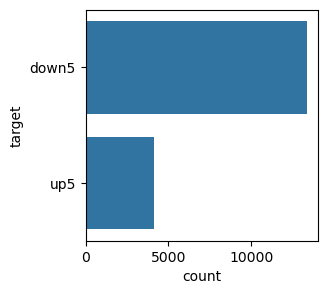

```python
plt.figure(figsize=(3,3))
sns.countplot(dat1['target'])
plt.show()
```

target(반응변수):클래스 불균형이 보인다.  
클래스 불균형은 파이프라인에서 처리한다.

#### 범주형 변수 범주별 빈도수 확인

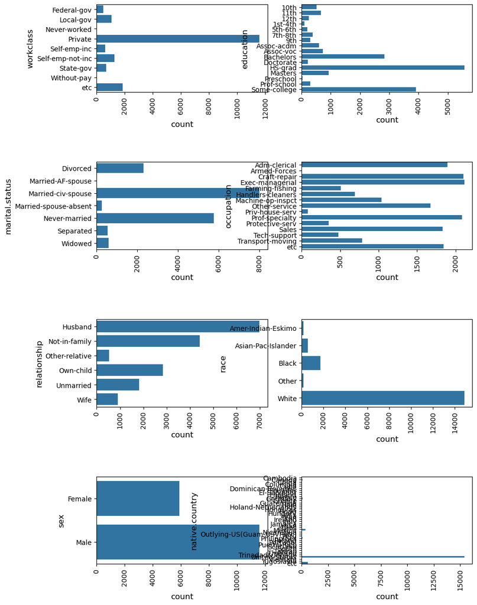

```python
dat_gca = dat1.select_dtypes('category')
dat_gca = dat_gca.drop('target',axis=1)
gname = dat_gca.columns.tolist()

fig = plt.figure(figsize=(10,15))
plt.subplots_adjust(wspace=0.2, hspace=0.8)
for i in range(len(gname)) :
    plt.rc('axes', labelsize=12)
    plt.rc('xtick', labelsize=10)
    plt.rc('ytick', labelsize=10)
    ax1 = fig.add_subplot(4,2,(i+1))
    sns.countplot(dat1[gname[i]], ax=ax1)
    plt.xticks(rotation=90)
plt.show()
```

범주형 예측변수 - 클래스 불균형이 심한 변수들은 범주 재구성 고려  
marital_status : married-civ-spouse를 제외하고 다른 범주는 소득이 5만달러 이하가 압도적으로 많다.  
relationship : husband, wife를 제외하고 다른 범주는 소득이 5만달러 이하가 압도적으로 많다.  
native_country : 'Unied-States'의 비율이 압도적으로 높다.'Unied-States'와 'Unied-States'아닌 두 개의 범주로 재구성 고려.

#### 수치형 변수 상관계수 확인

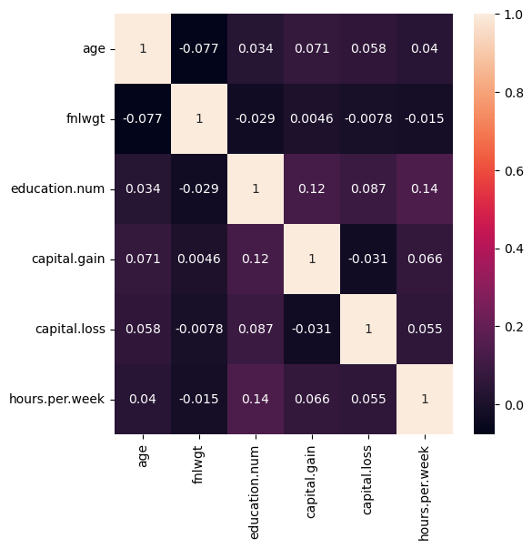

```python
plt.figure(figsize=(6,6))
corr = dat1.select_dtypes('number').corr()
sns.heatmap(corr, annot = True)
plt.show();
```

모두 약한 상관관계이다.

#### 수치형 변수 히스토그램

```
array([[<AxesSubplot:title={'center':'age'}>,
        <AxesSubplot:title={'center':'fnlwgt'}>],
       [<AxesSubplot:title={'center':'education.num'}>,
        <AxesSubplot:title={'center':'capital.gain'}>],
       [<AxesSubplot:title={'center':'capital.loss'}>,
        <AxesSubplot:title={'center':'hours.per.week'}>]], dtype=object)
```

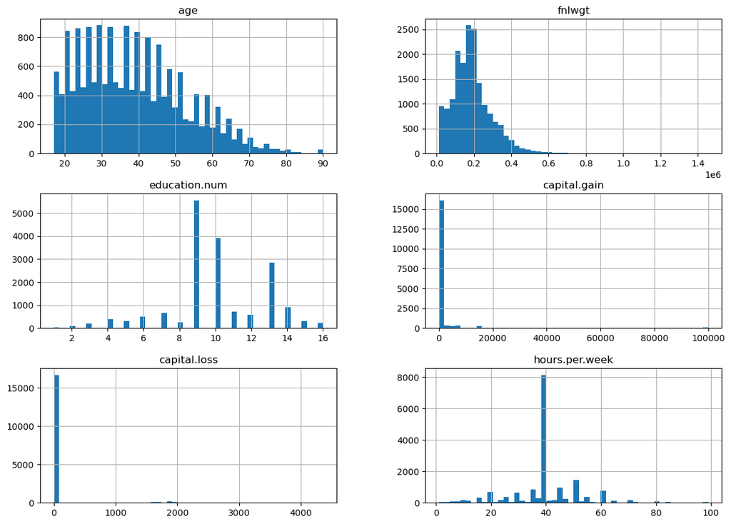

```python
dat.select_dtypes('number').hist(bins=50,figsize=(14, 10), layout=(3, 2), sharex=False, sharey=False)
```

capital_gain,capital_loss의 경우 0의 비율이 압도적으로 높다.

```python
print(len(dat1.loc[dat1['capital.gain']==0,'capital.gain']))
print(len(dat1.loc[dat1['capital.gain']!=0,'capital.gain']))
print(len(dat1.loc[dat1['capital.loss']==0,'capital.loss']))
print(len(dat1.loc[dat1['capital.loss']!=0,'capital.loss']))
```

```
16037
1443
16699
781
```

capital_gain,capital_loss 변수 : 0,!0로 구분된 추가 변수 필요.

#### 수치형 변수 boxplot

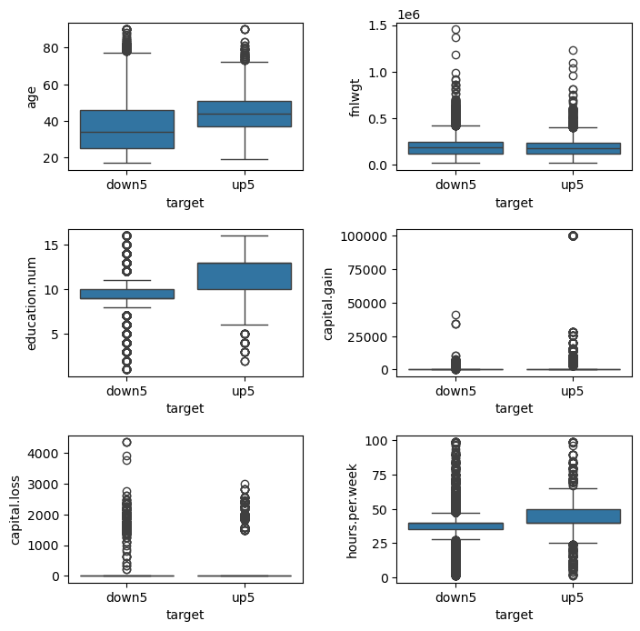

```python
dat_gnum = dat1.select_dtypes('number')
gname = dat_gnum.columns.tolist()

fig = plt.figure(figsize=(8,8))
plt.subplots_adjust(wspace=0.4, hspace=0.4)
for i in range(len(gname)) :
    plt.rc('axes', labelsize=10)
    plt.rc('xtick', labelsize=10)
    plt.rc('ytick', labelsize=10)
    ax1 = fig.add_subplot(3,2,(i+1))
    sns.boxplot(y=dat1[gname[i]],x=dat1['target'], ax=ax1)
    plt.xticks()
plt.show()
```

나이, 교육 수준, 주당 근무시간은 '5만 달러 이상'이 '5만달러 이하' 보다 높은 구간에 IQR이 위치해 있다.

#### 수치형 변수 이상치 개수 및 비율 확인

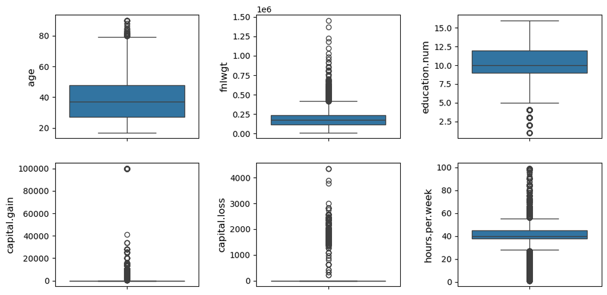

```python
dat_gnum = dat1.select_dtypes('number')
gname = dat_gnum.columns.tolist()

fig = plt.figure(figsize=(12,6))
plt.subplots_adjust(wspace=0.4, hspace=0.2)
for i in range(len(gname)) :
    plt.rc('axes', labelsize=12)
    plt.rc('xtick', labelsize=10)
    plt.rc('ytick', labelsize=10)
    ax1 = fig.add_subplot(2,3,(i+1))
    sns.boxplot(y=dat1[gname[i]], ax=ax1)
    plt.xticks()
plt.show()
```

#### 수치형 변수 이상치 개수 및 비율 확인

```python
def find_out(dat1):
    dat_gnum = dat1.select_dtypes('number')
    gname = dat_gnum.columns.tolist()
    for i in range(len(gname)) :
            Q1 = np.quantile(dat_gnum[gname[i]], 0.25)# 1
            Q3 = np.quantile(dat_gnum[gname[i]], 0.75)# 3
            IQR = Q3 - Q1
            UC = Q3 + (1.5 * IQR)
            LC = Q3 - (1.5 * IQR)
            isdf = dat_gnum.loc[(dat_gnum[gname[i]] > UC) | (dat_gnum[gname[i]] < LC), :]
            print(gname[i]," : ",round(len(isdf)/len(dat1),4))
```

```python
find_out(dat1)
```

```
age  :  0.0043
fnlwgt  :  0.1189
education.num  :  0.1241
capital.gain  :  0.0826
capital.loss  :  0.0447
hours.per.week  :  0.2673
```

#### 추가 전처리 고려 사항

1) education은 education_num과 동일하므로 education을 제외  
2) 결과변수 클래스 불균형 처리. smote알고리즘 방법 등  
3) 클래스 불균형이 심한 변수들은 범주 재구성, native_country변수 'Unied-States'와 'Unied-States'아닌 두 개의 범주로 재구성  
4) capital_gain,capital_loss 변수 : 0,!0로 구분된 추가 변수  
5) 이상치 제거 한 모델 성과와 비교 확인  
본 분석에서는 1),2),4)우선 적용, 나머지는 추후 확인

```python
dat1 = dat1.drop('education',axis=1)
```

```python
dat1.info()
```

```
<class 'pandas.core.frame.DataFrame'>
RangeIndex: 17480 entries, 0 to 17479
Data columns (total 14 columns):
 #   Column          Non-Null Count  Dtype
---  ------          --------------  -----
 0   age             17480 non-null  int64
 1   fnlwgt          17480 non-null  int64
 2   education.num   17480 non-null  int64
 3   capital.gain    17480 non-null  int64
 4   capital.loss    17480 non-null  int64
 5   hours.per.week  17480 non-null  int64
 6   workclass       17480 non-null  category
 7   marital.status  17480 non-null  category
 8   occupation      17480 non-null  category
 9   relationship    17480 non-null  category
 10  race            17480 non-null  category
 11  sex             17480 non-null  category
 12  native.country  17480 non-null  category
 13  target          17480 non-null  category
dtypes: category(8), int64(6)
memory usage: 959.5 KB
```

전처리  
capital_gain 이 0이면 0, 아니면 1로 변환후 범주형 변환  
capital_loss 이 0이면 0, 아니면 1로 변환후 범주형 변환

```python
dat1.loc[dat1['capital.gain']!=0,'capital.gain'] = 1
dat1.loc[dat1['capital.loss']!=0,'capital.loss'] = 1
```

```python
print(dat1['capital.gain'].unique())
print(dat1['capital.loss'].unique())
```

```
[0 1]
[0 1]
```

```python
dat1['capital.gain'] = dat1['capital.gain'].astype('category')
dat1['capital.loss'] = dat1['capital.loss'].astype('category')
```

#### 데이터 분할

```python
from sklearn.model_selection import train_test_split
```

```python
y = dat1.target
X = dat1.drop(['target'], axis = 1)
```

```python
X_train, X_test, y_train, y_test = train_test_split(X, y, test_size=0.2,stratify =y,  random_state=123) # 훈련 80 : 테스트 20 으로 분리
```

#### 파이프라인

```python
num_columns = X_train.select_dtypes('number').columns.tolist()
cat_columns = X_train.select_dtypes('category').columns.tolist()
```

```python
from sklearn.pipeline import Pipeline, make_pipeline
from sklearn.preprocessing import OneHotEncoder
```

범주형 : 원 핫 인코딩 - 독립변수 희귀 클래스를 하나로 묶기

```python
cat_preprocess = make_pipeline(
    OneHotEncoder(handle_unknown="infrequent_if_exist",
                  min_frequency=0.05,   sparse_output=False ))
```

연속형 : 정규화

```python
from sklearn.preprocessing import MinMaxScaler
num_preprocess = make_pipeline( MinMaxScaler() )
```

파이프 라인 결합

```python
from sklearn.compose import ColumnTransformer, make_column_transformer

preprocess = ColumnTransformer(
[("num", num_preprocess, num_columns),
("cat", cat_preprocess, cat_columns)]#,remainder='passthrough'
)
```

### 모델 결합 & 클래스불균형 처리 SMOTE

#### 1. XGBOOST

```python
import xgboost as xgb
from imblearn.pipeline import Pipeline as ImbPipeline
from imblearn.over_sampling import SMOTE

full_pipe = ImbPipeline(
    [("preprocess", preprocess),
     ("smote", SMOTE(random_state=1234, k_neighbors=5)),
     ("classifier", xgb.XGBClassifier())]
)
```

```python
from sklearn.model_selection import GridSearchCV, KFold
from sklearn.model_selection import cross_val_score
from sklearn.metrics import confusion_matrix, classification_report, accuracy_score, balanced_accuracy_score, roc_auc_score, roc_curve, RocCurveDisplay

from sklearn.preprocessing import LabelEncoder

cv = KFold(n_splits = 5, shuffle = True, random_state = 0)
```

```python
Xgb_param = {'classifier__learning_rate': np.arange(0.01, 0.3, 0.05)}

Xgb_search = GridSearchCV(estimator = full_pipe,
param_grid = Xgb_param,
cv = cv,
scoring = 'balanced_accuracy') # roc_auc, average_precision

le = LabelEncoder()
y_train_e = le.fit_transform(y_train)

Xgb_search.fit(X_train, y_train_e )
```

```
GridSearchCV(cv=KFold(n_splits=5, random_state=0, shuffle=True),
             estimator=Pipeline(steps=[('preprocess',
                                        ColumnTransformer(transformers=[('num',
                                                                         Pipeline(steps=[('minmaxscaler',
                                                                                          MinMaxScaler())]),
                                                                         ['age',
                                                                          'fnlwgt',
                                                                          'education.num',
                                                                          'hours.per.week']),
                                                                        ('cat',
                                                                         Pipeline(steps=[('onehotencoder',
                                                                                          OneHotEncoder(handle_unknown='infrequent_if_exist',
                                                                                                        min_frequency=0.0...
                                                      max_cat_threshold=None,
                                                      max_cat_to_onehot=None,
                                                      max_delta_step=None,
                                                      max_depth=None,
                                                      max_leaves=None,
                                                      min_child_weight=None,
                                                      missing=nan,
                                                      monotone_constraints=None,
                                                      multi_strategy=None,
                                                      n_estimators=None,
                                                      n_jobs=None,
                                                      num_parallel_tree=None,
                                                      random_state=None, ...))]),
             param_grid={'classifier__learning_rate': array([0.01, 0.06, 0.11, 0.16, 0.21, 0.26])},
             scoring='balanced_accuracy')
```

#### 교차검증 성능

```python
print(Xgb_search.best_params_)
print(Xgb_search.best_score_)
print('Xgb best score : ', Xgb_search.best_score_)
```

```
{'classifier__learning_rate': 0.01}
0.8062499114585042
Xgb best score :  0.8062499114585042
```

#### 2. RandomForest

```python
from sklearn.ensemble import RandomForestClassifier

full_pipe = ImbPipeline(
    [("preprocess", preprocess),
     ("smote", SMOTE(random_state=1234, k_neighbors=5)),# 1234:재현성 보장용,  k_neighbors 3~7 정도
     ("classifier", RandomForestClassifier()) ]
)
```

```python
cv = KFold(n_splits = 5, shuffle = True, random_state = 0)

RandomForest_param = {'classifier__max_features': np.arange(0.5, 1, 0.1)}

RandomForest_search = GridSearchCV(estimator = full_pipe,
param_grid = RandomForest_param,
cv = cv,
scoring = 'balanced_accuracy') # roc_auc, average_precision
RandomForest_search.fit(X_train, y_train )
```

```
GridSearchCV(cv=KFold(n_splits=5, random_state=0, shuffle=True),
             estimator=Pipeline(steps=[('preprocess',
                                        ColumnTransformer(transformers=[('num',
                                                                         Pipeline(steps=[('minmaxscaler',
                                                                                          MinMaxScaler())]),
                                                                         ['age',
                                                                          'fnlwgt',
                                                                          'education.num',
                                                                          'hours.per.week']),
                                                                        ('cat',
                                                                         Pipeline(steps=[('onehotencoder',
                                                                                          OneHotEncoder(handle_unknown='infrequent_if_exist',
                                                                                                        min_frequency=0.05,
                                                                                                        sparse_output=False))]),
                                                                         ['capital.gain',
                                                                          'capital.loss',
                                                                          'workclass',
                                                                          'marital.status',
                                                                          'occupation',
                                                                          'relationship',
                                                                          'race',
                                                                          'sex',
                                                                          'native.country'])])),
                                       ('smote', SMOTE(random_state=1234)),
                                       ('classifier',
                                        RandomForestClassifier())]),
             param_grid={'classifier__max_features': array([0.5, 0.6, 0.7, 0.8, 0.9])},
             scoring='balanced_accuracy')
```

#### 교차검증 성능

```python
print(RandomForest_search.best_params_)
print(RandomForest_search.best_score_)
print('RandomForest best score : ', RandomForest_search.best_score_)#### 교차검증 성능
```

```
{'classifier__max_features': 0.5}
0.7698244632932263
RandomForest best score :  0.7698244632932263
```

XGBOOST가 랜덤포레스트보다 더 우수하다.

```python
pred = Xgb_search.predict(X_test)
pred1 = le.inverse_transform(pred )
cmr = classification_report(y_test, pred1, target_names = ['down5', 'up5'])
print(cmr)
```

```
              precision    recall  f1-score   support

       down5       0.94      0.77      0.84      2675
         up5       0.53      0.84      0.65       821

    accuracy                           0.78      3496
   macro avg       0.73      0.81      0.75      3496
weighted avg       0.84      0.78      0.80      3496
```

#### 변수 중요도 Permutation importance plot

```python
from sklearn.inspection import permutation_importance

feature_importances = permutation_importance(
Xgb_search,X_train, y_train_e , n_repeats=10, random_state=42
)
```

[output not shown]

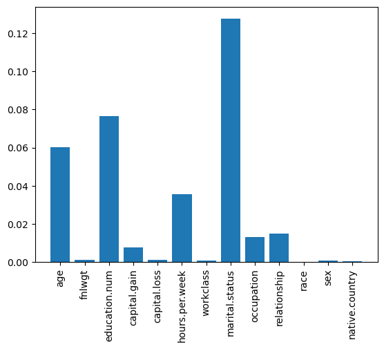

```python
import matplotlib.pyplot as plt

features = X_train.columns
importances = feature_importances.importances_mean
plt.bar(features, importances)
plt.xticks(rotation=90)
```